# Degrees that pay you back

Pablo

March 5, 2019

This is a project I completed from Datacamp.com

## 1. Which college majors will pay the bills?

Wondering if that Philosophy major will really help you pay the bills? Think you’re set with an Engineering degree? Choosing a college major is a complex decision evaluating personal interest, difficulty, and career prospects. Your first paycheck right out of college might say a lot about your salary potential by mid-career. Whether you’re in school or navigating the postgrad world, join me as we explore the short and long term financial implications of this *major* decision.

In this notebook, we’ll be using data collected from a year-long survey of 1.2 million people with only a bachelor’s degree by PayScale Inc., made available [here](http://online.wsj.com/public/resources/documents/info-Degrees_that_Pay_you_Back-sort.html?mod=article_inline) by the Wall Street Journal for their article [Ivy League’s Big Edge: Starting Pay](https://www.wsj.com/articles/SB121746658635199271)

After doing some data clean up, we’ll compare the recommendations from three different methods for determining the optimal number of clusters, apply a k-means clustering analysis, and visualize the results.

To begin, let’s prepare by loading the following packages: `tidyverse`, `dplyr`, `readr`,`ggplot2`, `cluster`,and `factoextra`. We’ll then import the data from **degrees-that-pay-back.csv**, and take a quick look at what we’re working with.

```r
# Load relevant packages
library(tidyr)
library(dplyr)
library(readr)
library(ggplot2)
library(cluster)
library(factoextra)
```

```r
# Read in the dataset
degrees <- read_csv("degrees-that-pay-back.csv", col_names= c( "College.Major", "Starting.Median.Salary","Mid.Career.Median.Salary", "Career.Percent.Growth", "Percentile.10", "Percentile.25", "Percentile.75", "Percentile.90"), skip=1)
```

```r
# Display the first few rows and a summary of the data frame
head(degrees)
```

```
## # A tibble: 6 x 8
##   College.Major Starting.Median~ Mid.Career.Medi~ Career.Percent.~
##   <chr>         <chr>            <chr>                       <dbl>
## 1 Accounting    $46,000.00       $77,100.00                   67.6
## 2 Aerospace En~ $57,700.00       $101,000.00                  75
## 3 Agriculture   $42,600.00       $71,900.00                   68.8
## 4 Anthropology  $36,800.00       $61,500.00                   67.1
## 5 Architecture  $41,600.00       $76,800.00                   84.6
## 6 Art History   $35,800.00       $64,900.00                   81.3
## # ... with 4 more variables: Percentile.10 <chr>, Percentile.25 <chr>,
## #   Percentile.75 <chr>, Percentile.90 <chr>
```

```r
summary(degrees)
```

```
##  College.Major      Starting.Median.Salary Mid.Career.Median.Salary
##  Length:50          Length:50              Length:50
##  Class :character   Class :character       Class :character
##  Mode  :character   Mode  :character       Mode  :character
##
##
##
##  Career.Percent.Growth Percentile.10      Percentile.25
##  Min.   : 23.40        Length:50          Length:50
##  1st Qu.: 59.12        Class :character   Class :character
##  Median : 67.80        Mode  :character   Mode  :character
##  Mean   : 69.27
##  3rd Qu.: 82.42
##  Max.   :103.50
##  Percentile.75      Percentile.90
##  Length:50          Length:50
##  Class :character   Class :character
##  Mode  :character   Mode  :character
##
##
##
```

## 2. Currency and strings and percents, oh my!

Let’s strip those special characters using the gsub function and convert all of our columns except College.Major to numeric. While we’re at it, we can also convert the Career.Percent.Growth column to a decimal value

```r
# Clean up the data
degrees_clean <- degrees %>%
    mutate_at(vars( Starting.Median.Salary:Percentile.90), function(x) as.numeric(gsub("[\\$,]","",x))) %>% mutate(Career.Percent.Growth = Career.Percent.Growth / 100)
```

## 3. The elbow method

Great! Now that we have a more manageable dataset, let’s begin our clustering analysis by determining how many clusters we should be modeling. The best number of clusters for an unlabeled dataset is not always a clear-cut answer, but fortunately there are several techniques to help us optimize. We’ll work with three different methods to compare recommendations:

- Elbow Method
- Silhouette Method
- Gap Statistic Method

First up will be the Elbow Method. This method plots the percent variance against the number of clusters. The “elbow” bend of the curve indicates the optimal point at which adding more clusters will no longer explain a significant amount of the variance. To begin, let’s select and scale the following features to base our clusters on: Starting.Median.Salary, Mid.Career.Median.Salary, Perc.10, and Perc.90. Then we’ll use the fancy fviz_nbclust function from the factoextra library to determine and visualize the optimal number of clusters.

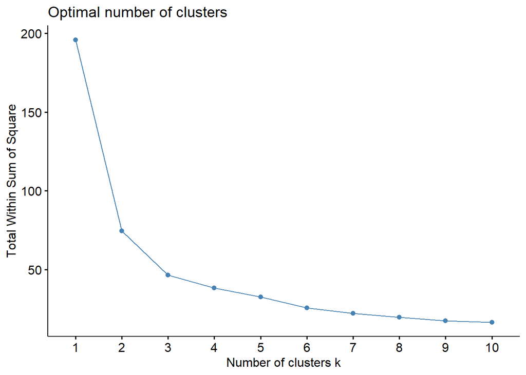

```r
# Select and scale the relevant features and store as k_means_data
k_means_data <- degrees_clean %>% select(Starting.Median.Salary, Mid.Career.Median.Salary, Percentile.10,Percentile.90) %>% scale()
# Run the fviz_nbclust function with our selected data and method "wss"
elbow_method <- fviz_nbclust(k_means_data, FUNcluster = kmeans, method = "wss")

# View the plot
elbow_method
```

## 4. The silhouette method

Wow, that fviz_nbclust function was pretty nifty. Instead of needing to “manually” apply the elbow method by running multiple k_means models and plotting the calculated the total within cluster sum of squares for each potential value of k, fviz_nbclust handled all of this for us behind the scenes. Can we use it for the Silhouette Method as well? The Silhouette Method will evaluate the quality of clusters by how well each point fits within a cluster, maximizing average “silhouette” width.

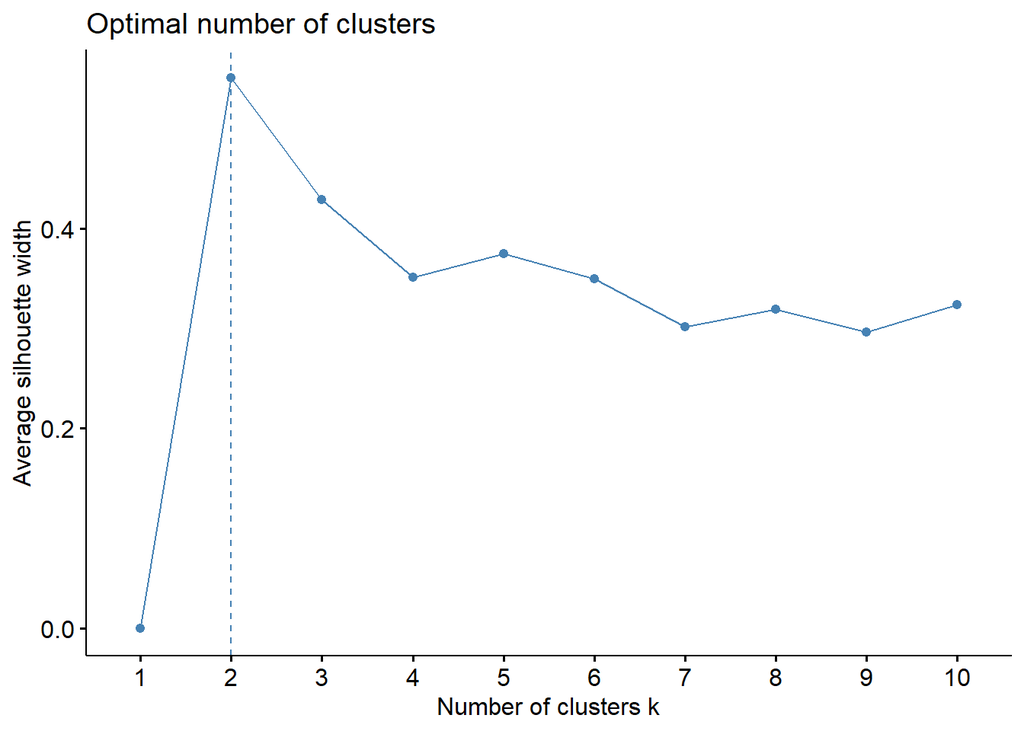

```r
# Run the fviz_nbclust function with the method "silhouette"
silhouette_method <- fviz_nbclust(k_means_data, FUNcluster = kmeans, method = "silhouette")

# View the plot
silhouette_method
```

## 5. The gap statistic method

it seems that our two methods so far disagree on the optimal number of clusters… Time to pull out the tie breaker. For our final method, let’s see what the Gap Statistic Method has to say about this. The Gap Statistic Method will compare the total variation within clusters for different values of k to the null hypothesis, maximizing the “gap.” The “null hypothesis” refers to a uniformly distributed simulated reference dataset with no observable clusters, generated by aligning with the principle components of our original dataset. In other words, how much more variance is explained by k clusters in our dataset than in a fake dataset where all majors have equal salary potential? Fortunately, we have the clusGap function to calculate this behind the scenes and the fviz_gap_stat function to visualize the results.

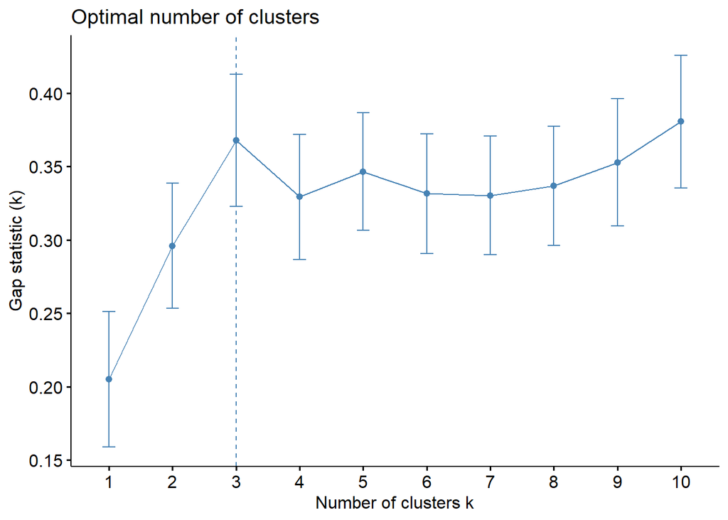

```r
# Use the clusGap function to apply the Gap Statistic Method
gap_stat <- clusGap(k_means_data, FUN = kmeans, nstart = 25, K.max = 10, B = 50)

# Use the fviz_gap_stat function to vizualize the results
gap_stat_method <- fviz_gap_stat(gap_stat)

# View the plot
gap_stat_method
```

## 6. K-means algorithm

Looks like the Gap Statistic Method agreed with the Elbow Method! According to majority rule, let’s use 3 for our optimal number of clusters. With this information, we can now run our k-means algorithm on the selected data. We will then add the resulting cluster information to label our original dataframe.

```r
# Set a random seed
set.seed(111)
# Set k equal to the optimal number of clusters
num_clusters <- 3

# Run the k-means algorithm
k_means <- kmeans(k_means_data, centers = num_clusters, iter.max = 15, nstart = 25)

# Label the clusters of degrees_clean
degrees_labeled <- degrees_clean %>%
    mutate(clusters = k_means$cluster)
```

## 7. Visualizing the clusters

Now for the pretty part: visualizing our results. First let’s take a look at how each cluster compares in Starting vs. Mid Career Median Salaries. What do the clusters say about the relationship between Starting and Mid Career salaries?

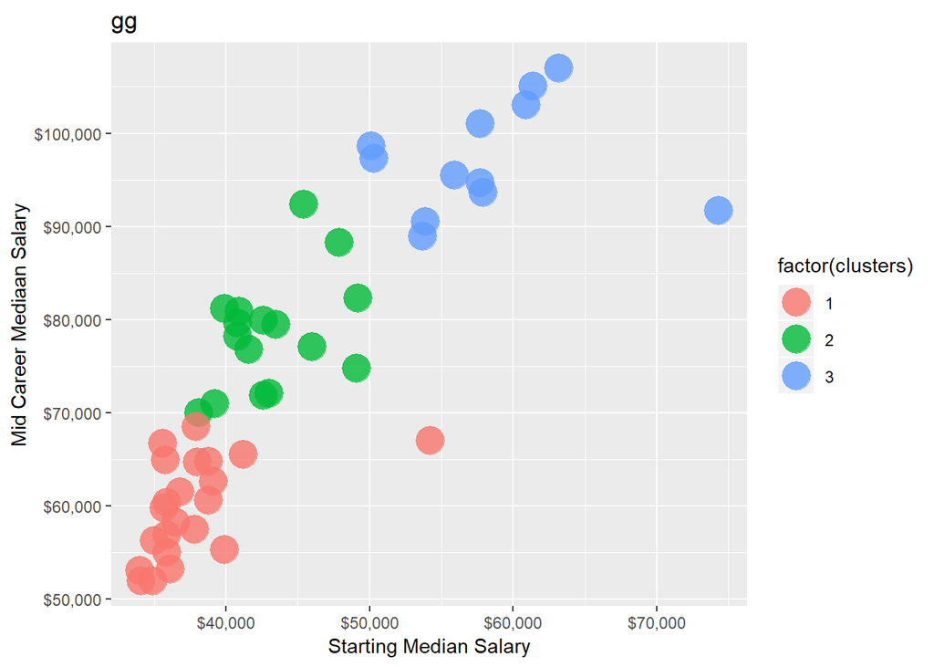

```r
# Graph the clusters by Starting and Mid Career Median Salaries
career_growth <- ggplot(degrees_labeled, aes(Starting.Median.Salary, Mid.Career.Median.Salary, color = factor(clusters))) +
                        geom_point(aes(), alpha = 4/5, size = 7) +
                        xlab("Starting Median Salary") +
                        ylab("Mid Career Mediaan Salary") +
                        ggtitle("gg") +
                        scale_x_continuous(labels = scales::dollar) +
                        scale_y_continuous(labels = scales::dollar)


# View the plot
career_growth
```

## 8. A deeper dive into the clusters

```r
# Use the gather function to reshape degrees and
# use mutate() to reorder the new percentile column
degrees_perc <- degrees_labeled %>%
    select(College.Major, Percentile.10, Percentile.25, Mid.Career.Median.Salary, Percentile.75, Percentile.90, clusters) %>%
    gather(key = percentile, value = salary,
           -c(College.Major, clusters)) %>%
            mutate(percentile = factor(percentile, levels=c("Percentile.10", "Percentile.25", "Mid.Career.Median.Salary","Percentile.75", "Percentile.90")))
```

## 9. The liberal arts cluster

Let’s graph Cluster 1 and examine the results. These Liberal Arts majors may represent the lowest percentiles with limited growth opportunity, but there is hope for those who make it! Music is our riskiest major with the lowest 10th percentile salary, but Drama wins the highest growth potential in the 90th percentile for this cluster (so don’t let go of those Hollywood dreams!). Nursing is the outlier culprit of cluster number 1, with a higher safety net in the lowest percentile to the median. Otherwise, this cluster does represent the majors with limited growth opportunity. An aside: It’s worth noting that most of these majors leading to lower-paying jobs are women-dominated, according to this Glassdoor study. According to the research: “The single biggest cause of the gender pay gap is occupation and industry sorting of men and women into jobs that pay differently throughout the economy. In the U.S., occupation and industry sorting explains 54 percent of the overall pay gap-by far the largest factor.” Does this imply that women are statistically choosing majors with lower pay potential, or do certain jobs pay less because women choose them…?

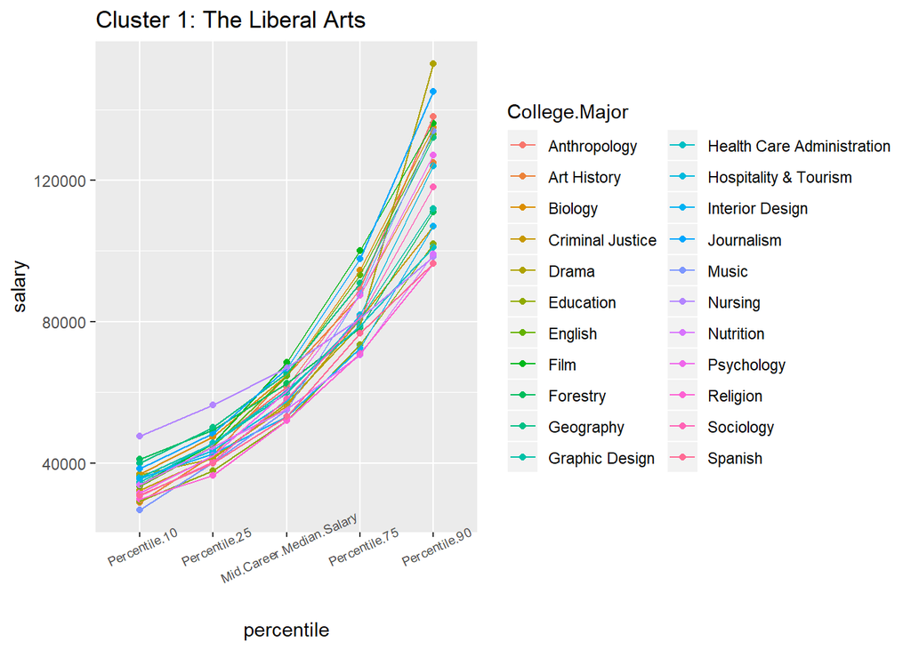

```r
# Graph the majors of Cluster 1 by percentile
cluster_1 <- degrees_perc %>% filter(clusters == 1) %>%
    ggplot(aes(x= percentile, y = salary, color = College.Major, group = College.Major)) +
    geom_point()+
    geom_line() +
    ggtitle("Cluster 1: The Liberal Arts")+
    theme(axis.text.x = element_text(size = 7, angle = 25))


# View the plot
cluster_1
```

## 11. The over achiever cluster

Finally, let’s visualize Cluster 3. If you want financial security, these are the majors to choose from. Besides our one previously observed outlier now identifiable as Physician Assistant lagging in the highest percentiles, these heavy hitters and solid engineers represent the highest growth potential in the 90th percentile, as well as the best security in the 10th percentile rankings. Maybe those Freakonomics guys are on to something…

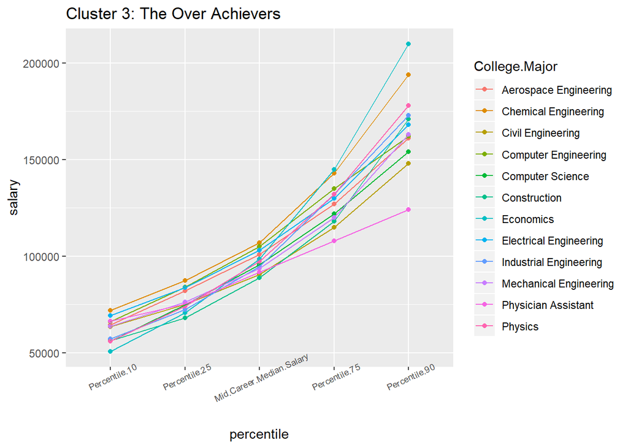

```r
# Modify the previous plot to display Cluster 3
cluster_3 <- degrees_perc %>% filter(clusters == 3) %>%
    ggplot(aes(x= percentile, y = salary, color = College.Major, group = College.Major)) +
    geom_point()+
    geom_line() +
    ggtitle("Cluster 3: The Over Achievers")+
    theme(axis.text.x = element_text(size = 7, angle = 25))

# View the plot
cluster_3
```

## 12. Every major’s wonderful

```r
# Sort degrees by Career.Percent.Growth
degrees_labeled %>% arrange(desc(Career.Percent.Growth))
```

```
## # A tibble: 50 x 9
##    College.Major Starting.Median~ Mid.Career.Medi~ Career.Percent.~
##    <chr>                    <dbl>            <dbl>            <dbl>
##  1 Math                     45400            92400            1.03
##  2 Philosophy               39900            81200            1.03
##  3 Internationa~            40900            80900            0.978
##  4 Economics                50100            98600            0.968
##  5 Marketing                40800            79600            0.951
##  6 Physics                  50300            97300            0.934
##  7 Political Sc~            40800            78200            0.917
##  8 Chemistry                42600            79900            0.876
##  9 Journalism               35600            66700            0.874
## 10 Architecture             41600            76800            0.846
## # ... with 40 more rows, and 5 more variables: Percentile.10 <dbl>,
## #   Percentile.25 <dbl>, Percentile.75 <dbl>, Percentile.90 <dbl>,
## #   clusters <int>
```

```r
# Identify the two majors tied for highest career growth potential
highest_career_growth <- c('Math','Philosophy')
```